# data_exploration

## Data Exploration

A notebook to investigate the relationships between the different variables, especially the target variable.

```python
import seaborn as sns
import pandas as pd
import matplotlib.pyplot as plt
import numpy as np
import random

from sklearn.preprocessing import LabelEncoder
from scipy.stats import ttest_rel
from sklearn.feature_selection import SelectKBest, chi2

import ml_colon
import ml_colon.data_preparation
```

### Load raw Data

```python
descr_df = pd.read_csv(ml_colon.DATA_DIR / "data_description.csv", index_col="column_name")
df = ml_colon.data_preparation.get_df_from_csv()
```

## Exploring

#### Column: Bits

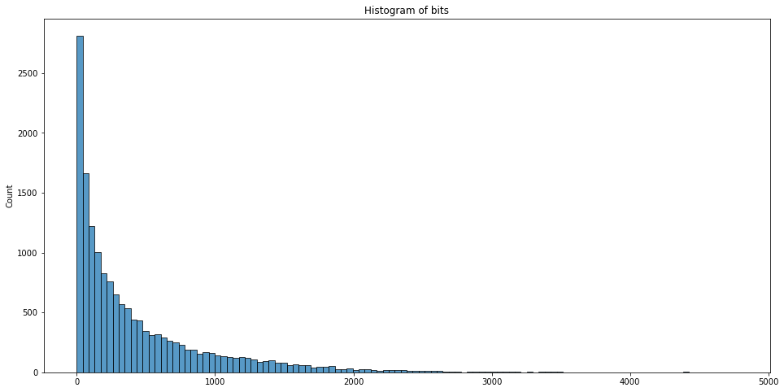

```python
fig, ax = plt.subplots(figsize=(16,8))
ax.set_title(f"Histogram of bits")
sns.histplot(df["bits"].values, ax=ax)
```

```python
pd.cut(df["bits"], bins=[0, 8, 16, 32, 64, 124], include_lowest=False).value_counts(sort=False)
```

```
(0, 8]        696
(8, 16]       419
(16, 32]      964
(32, 64]     1494
(64, 124]    1818
Name: bits, dtype: int64
```

Let's identify the characteristics of the rows whose value of "bits" is 0.

```python
df_bits_zero = df.loc[df.bits == 0]
print(f"There are {len(df_bits_zero)} rows with bits = 0")
```

```
There are 147 rows with bits = 0
```

```python
_descr_df = df_bits_zero.describe()

other_cols_zero = list(_descr_df.columns[_descr_df.loc["mean"].eq(0)])

print(f"Other columns that are also 0: {other_cols_zero}")
```

```
Other columns that are also 0: ['bits', 'intra_parts', 'inter_16x16_parts', 'inter_4x4_parts', 'inter_other_parts', 'non_zero_pixels', 'block_movement_h', 'block_movement_v', 'var_movement_h', 'var_movement_v']
```

The rows where the value of `bits` are 0 also have 0 in `bits`, `intra_parts`, `inter_16x16_parts`, `inter_4x4_parts`, `inter_other_parts`, `non_zero_pixels`, `block_movement_h`, `block_movement_v`, `var_movement_h` and `var_movement_v`.

#### Assumption: Redundant rows

When the `bits = 0` we think that it could mean that the information was already encoded in another frame. In other words, they are already represented on the previous frame. To verify the assumption, it is necessary to check if we find duplicated rows in the dataframe disregarding the column `bits`.

```python
df.duplicated(subset=[c for c in df.columns if c != "bits"]).any()
```

```
False
```

The quick check shows that when considering all columns except `bits` we do not find any duplicated rows. Meaning our assumption was wrong. Furthermore this also means that there are in general no duplicated rows in the dataset.

```python
df.duplicated().any()
```

```
False
```

Since there are multiple continuous variables in the dataset it is worth to see if there combination of these columns uniquely identifies a row (just out of curiosity)

```python
df.duplicated(subset=["cost_1", "cost_2", "movement_level"]).sum()
```

```
1
```

We find that the combination of the values in the columns `cost_1`, `cost_2` and `movement_level` is already almost unique. Only 2 rows have the exact same values for these 3 columns.

```python
df.groupby(["cost_1", "cost_2", "movement_level"]).filter(lambda x: x["bits"].count() > 1)[["bits", "cost_1", "cost_2", "movement_level"]]
```

|  | bits | cost_1 | cost_2 | movement_level |
| --- | --- | --- | --- | --- |
| 13179 | 0 | 2398.0 | 2273.0 | 10833854 |
| 13595 | 374 | 2398.0 | 2273.0 | 10833854 |

### Relationships with target variable

In this section we will be looking for high discriminators to determine if a block is relevant. First we produce boxplots for every continuous variable. This could help to see if one group has a different mean/distribution than the other group in the variable relevant.

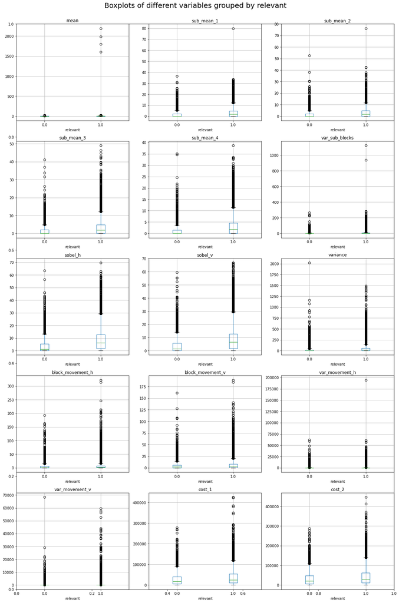

```python
fig, ax = plt.subplots(figsize=(16,25))

for num, y in enumerate(df.columns[11:-1]):
    ax1 = fig.add_subplot(5,3,num+1)
    ax1 = df.boxplot(y, by='relevant', ax=ax1)

plt.suptitle("Boxplots of different variables grouped by relevant", size=20)
plt.tight_layout(rect=[0, 0.03, 1, 0.98])
```

There seem to be a lot of outliers for the different variables and groups. Some variables seem interesting as the mean of the two groups differs a bit.

Now lets take a look at the relationship of the discrete variables with the target variable. For this part, we group by each discrete value and see what percentage in that group has relevant = 1.

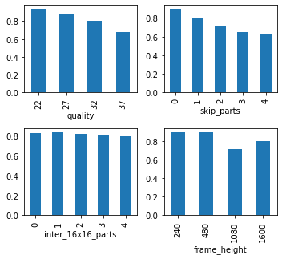

```python
fig, axes = plt.subplots(nrows=2, ncols=2, figsize=(5,5))
col_num = [0, 3, 4, 9] # columns quality, skip_parts, inter_16x16_parts and frame_height

for ax, y in zip(axes.flatten(), df.columns[col_num]):
    df.groupby(y).mean()['relevant'].plot(ax=ax, kind='bar')

plt.suptitle("")
plt.tight_layout(rect=[0, 0.03, 1, 0.98])
```

Two discrete variables showed many different unique values. Therefore, we handle them as continuous variable in this part of the analysis. We use boxplots to see the different distributions of the data for the groups of relevant.

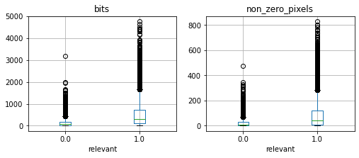

```python
fig, axes = plt.subplots(nrows=1, ncols=2, figsize=(8,3))
col_name = ['bits', 'non_zero_pixels']

for ax, y in zip(axes.flatten(), col_name):
    df.boxplot(y, by='relevant', ax=ax)
plt.suptitle("")
```

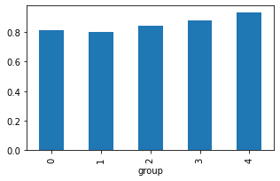

```python
fig, ax = plt.subplots(figsize=(5,3))
proc_df = df[['intra_parts', 'relevant']].copy()
proc_df['group'] = proc_df['intra_parts'] // 10
proc_df = proc_df.replace({"group": {3: 2, 4:3, 6:4}})
proc_df.groupby('group')['relevant'].mean().plot(kind='bar')
```

## Correlation Analysis

In this section, the correlations between all variables are investigated.

First, in order to consider which variables should be constant and categorical we explore the number of unique values of each of them

```python
df.nunique()
```

```
quality                  4
bits                  2106
intra_parts             15
skip_parts               5
inter_16x16_parts        5
inter_4x4_parts         12
inter_other_parts       28
non_zero_pixels        568
frame_width              4
frame_height             4
movement_level         205
mean                  6599
sub_mean_1            3123
sub_mean_2            3022
sub_mean_3            3072
sub_mean_4            2975
var_sub_blocks       11457
sobel_h               9908
sobel_v               9896
variance             12001
block_movement_h      2368
block_movement_v      2221
var_movement_h        8427
var_movement_v        8450
cost_1               14378
cost_2               14538
relevant                 2
dtype: int64
```

We split into continuous and constant variables

```python
cat = df.loc[:, df.nunique() < 29]
cont = df.loc[:, df.nunique() >= 29]
varlist = cont.columns.tolist()
varlist.append('relevant')
contRelv = df[varlist]
```

```python
contRelv.groupby('relevant').mean()
```

| relevant | bits | non_zero_pixels | movement_level | mean | sub_mean_1 | sub_mean_2 | sub_mean_3 | sub_mean_4 | var_sub_blocks | sobel_h | sobel_v | variance | block_movement_h | block_movement_v | var_movement_h | var_movement_v | cost_1 | cost_2 |
| --- | --- | --- | --- | --- | --- | --- | --- | --- | --- | --- | --- | --- | --- | --- | --- | --- | --- | --- |
| 0.0 | 151.527094 | 21.776918 | 4.857270e+06 | 1.579388 | 1.772326 | 1.684585 | 1.589222 | 1.271418 | 4.234237 | 4.183534 | 4.216856 | 29.598292 | 7.685221 | 5.121575 | 977.899925 | 411.026926 | 30345.427164 | 34941.264344 |
| 1.0 | 514.109076 | 85.353147 | 3.856880e+06 | 3.874461 | 3.441059 | 3.225339 | 3.346922 | 3.189547 | 7.055798 | 8.857525 | 9.146477 | 58.460886 | 8.097799 | 7.159843 | 812.707176 | 509.461132 | 38368.758969 | 43593.241172 |

In this table we can check the difference between the relevant categories, which looks significative

We save a copy of the main dataframe for further analysis.

```python
dftest=df.copy()
```

```python
def equal_test(df, variables, y):
    for var in variables:
        group0 = df.loc[df[y] == 0][var].tolist()
        group1 = df.loc[df[y] == 1][var].tolist()
        print(var)
        # Some variables have different length depending the group
        maxSize = max(len(group0), len(group1))
        group0 = random.choices(group0, k = maxSize)
        group1 = random.choices(group1, k = maxSize)

        if ttest_rel(group0, group1).pvalue >= 0.5:
            print("The groups have the same mean.")
        else:
            print("The groups are different.")
```

With this function we make use of the T-test in order to confirm if the groups are statistically different

```python
equal_test(contRelv, contRelv.columns[:-1].tolist(), contRelv.columns[-1])
```

```
bits
The groups are different.
non_zero_pixels
The groups are different.
movement_level
The groups are different.
mean
The groups are different.
sub_mean_1
The groups are different.
sub_mean_2
The groups are different.
sub_mean_3
The groups are different.
sub_mean_4
The groups are different.
var_sub_blocks
The groups are different.
sobel_h
The groups are different.
sobel_v
The groups are different.
variance
The groups are different.
block_movement_h
The groups are different.
block_movement_v
The groups are different.
var_movement_h
The groups are different.
var_movement_v
The groups are different.
cost_1
The groups are different.
cost_2
The groups are different.
```

Now we can see how the categorical variables correlate with the relevant variable

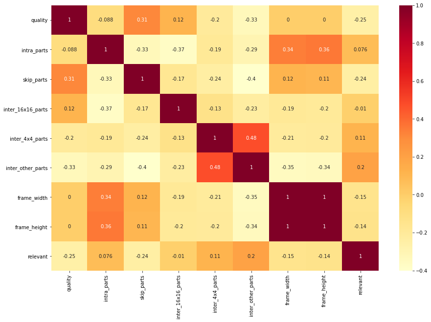

```python
plt.figure(figsize = (15, 10))
corr_mtx = cat.corr()
sns.heatmap(corr_mtx, annot = True, cmap = "YlOrRd")
```

Now we do the same with the continuous variables

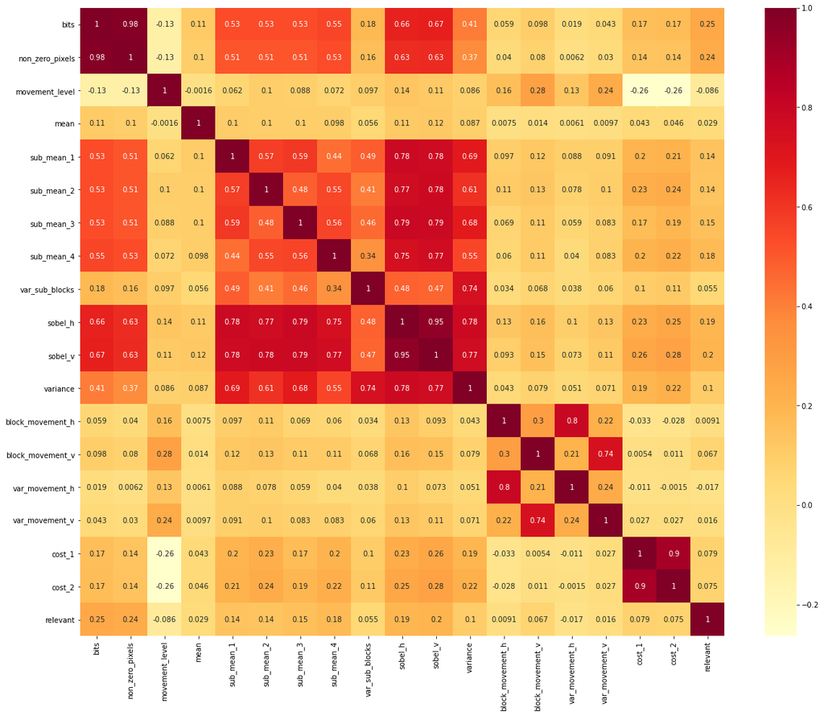

```python
plt.figure(figsize = (20, 16))
corr_mtx = contRelv.corr()
sns.heatmap(corr_mtx, annot = True, cmap = "YlOrRd")
```

We reduce the number of variables in order to make a more comprenhensive correlation analysis. Some of the variables are highly correlated and their descriptions help to understand how this reductions can me done. After creating new variables we delete the old ones.

In the first case we generate a new variable combining frame_height, frame_width and non_zero_pixels in order to obtain precise pixel infromation of the frame.

```python
df["pixel_frame"] = df['non_zero_pixels'] / (df['frame_height'] * df['frame_width'])

df = df.drop(['frame_height', 'frame_width', 'non_zero_pixels'], axis = 1)
```

For the sub_mean variable we have put all of them together in order to reduce their correlation.

```python
df['sub_mean'] = (df['sub_mean_1'] + df['sub_mean_2'] + df['sub_mean_3'] + df['sub_mean_4']) / 4

df = df.drop(['sub_mean_1', 'sub_mean_2', 'sub_mean_3', 'sub_mean_4'], axis = 1)
```

The sobel variables make reference to the mean of the pixels of the encoded block after applying the Sobel operator in vertical and horizontal direction. So we can combine them easily in order to obtain a mean of both of them.

```python
df['sobel_hv'] = (df['sobel_h'] + df['sobel_v']) / 2

df = df.drop(['sobel_h', 'sobel_v'], axis = 1)
```

This variables make reference to the measure of the movement and variance of a certain block in vertical and horizontal. As it is not relevant for this project to keep them separated we can obtain a single variable collecting a mean of this information.

```python
df['movement_var'] = ((df['block_movement_h'] / df['var_movement_h']) + (df['block_movement_v'] / df['var_movement_v'])) / 2

df = df.drop(['block_movement_h', 'block_movement_v', 'var_movement_h', 'var_movement_v'], axis = 1)
```

We make the same combination with the cost variables so we can obtain a better correlation analysis.

```python
df['cost'] = (df['cost_1'] + df['cost_2']) / 2

df = df.drop(['cost_1', 'cost_2'], axis = 1)
```

Now we can check if the correlation have been improved with the transformed variables.

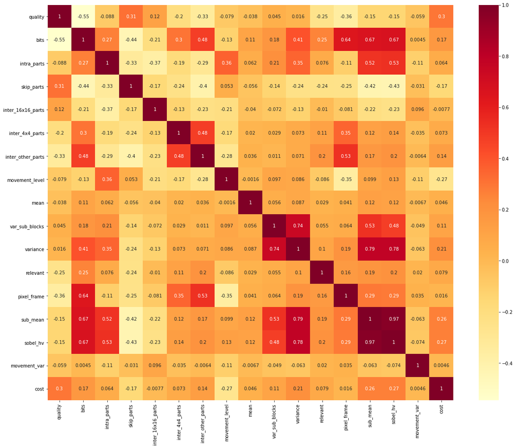

```python
plt.figure(figsize = (20, 16))
corr_mtx = df.corr()
sns.heatmap(corr_mtx, annot = True, cmap = "YlOrRd")
```

By checking the correlation we can reduce the number of variables but the main method used in this project works under the SelectKBest function.

```python
df = df.drop(["sobel_hv", "sub_mean", "variance", "bits", "inter_other_parts"], axis = 1)
```

Now we generate the correlation matrix showing the improvement of the results for the target variable.

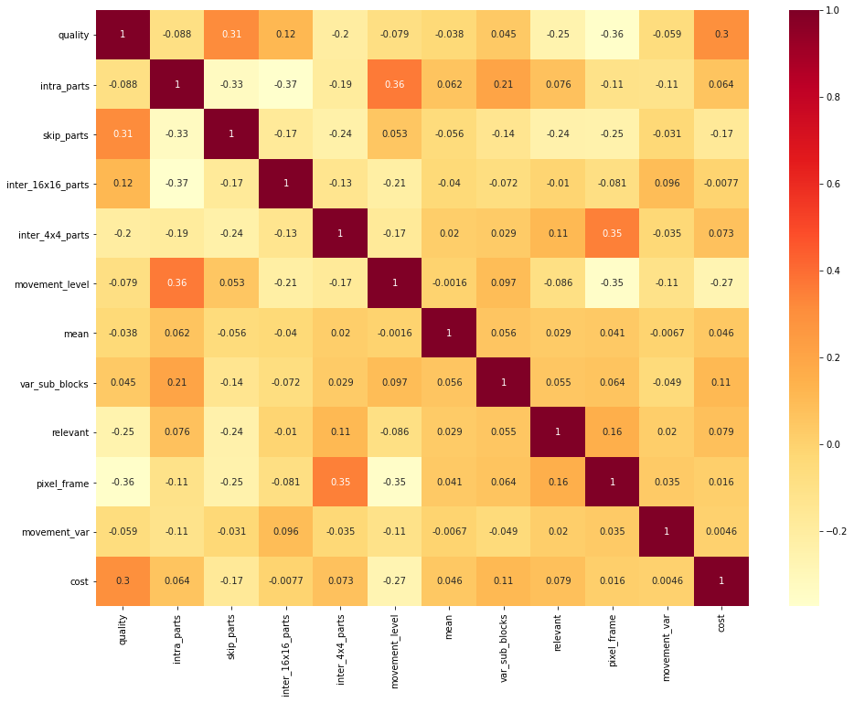

```python
plt.figure(figsize = (16, 12))
corr_mtx = df.corr()
sns.heatmap(corr_mtx, annot = True, cmap = "YlOrRd")
```

Now we can check if the continuous variables that are still in the analysis are statistically different or if they have the same mean.

```python
cont = df.loc[:, df.nunique() >= 29]
varlist = cont.columns.tolist()
varlist.append('relevant')
contRelv = df[varlist]
equal_test(contRelv, ["movement_level", "mean", "var_sub_blocks", "pixel_frame", "cost", "movement_var"], contRelv.columns[-1])
```

```
movement_level
The groups are different.
mean
The groups are different.
var_sub_blocks
The groups are different.
pixel_frame
The groups are different.
cost
The groups are different.
movement_var
The groups are different.
```

We decided to use the Label encoder instead of the One Hot Encoding as order could be important for further analysis.

```python
cat.head()
```

|  | quality | intra_parts | skip_parts | inter_16x16_parts | inter_4x4_parts | inter_other_parts | frame_width | frame_height | relevant |
| --- | --- | --- | --- | --- | --- | --- | --- | --- | --- |
| 0 | 22 | 0 | 0 | 1 | 3 | 21 | 416 | 240 | 1.0 |
| 1 | 22 | 0 | 2 | 0 | 3 | 8 | 416 | 240 | 1.0 |
| 2 | 22 | 0 | 0 | 0 | 0 | 8 | 416 | 240 | 1.0 |
| 3 | 22 | 0 | 0 | 0 | 18 | 20 | 416 | 240 | 1.0 |
| 4 | 22 | 0 | 0 | 1 | 3 | 8 | 416 | 240 | 1.0 |

```python
l_code = LabelEncoder()
for var in cat.columns:
    l_code.fit(cat[var])
    cat[var] = l_code.transform(cat[var])
```

```python
cat.head()
```

|  | quality | intra_parts | skip_parts | inter_16x16_parts | inter_4x4_parts | inter_other_parts | frame_width | frame_height | relevant |
| --- | --- | --- | --- | --- | --- | --- | --- | --- | --- |
| 0 | 0 | 0 | 0 | 1 | 1 | 21 | 0 | 0 | 1 |
| 1 | 0 | 0 | 2 | 0 | 1 | 8 | 0 | 0 | 1 |
| 2 | 0 | 0 | 0 | 0 | 0 | 8 | 0 | 0 | 1 |
| 3 | 0 | 0 | 0 | 0 | 6 | 20 | 0 | 0 | 1 |
| 4 | 0 | 0 | 0 | 1 | 1 | 8 | 0 | 0 | 1 |

## Feature Selection

In this section, feature selection will be used. This is done with the help of the SelectKBest function of Sklearn.

In order to perform the SelectKBest method it is necessary to delete the the Missing Values.

```python
dftest = dftest[~dftest.sub_mean_3.isnull()]
dftest = dftest[~dftest.relevant.isnull()]
dftest = dftest[~dftest.cost_2.isnull()]
```

In this step we create feature and target variable for Classification problem

```python
X_clf = dftest.loc[:,dftest.columns != 'relevant']

y_clf = dftest.loc[:,dftest.columns == 'relevant']

X_clf_new = SelectKBest(score_func = chi2, k = 10).fit_transform(X_clf, y_clf)

X_clf_new[:5]
```

```
array([[2.14300000e+03, 4.04000000e+02, 4.16000000e+02, 2.40000000e+02,
        4.23520000e+04, 8.75843350e+01, 1.07724000e+01, 8.57659900e+00,
        0.00000000e+00, 0.00000000e+00],
       [1.73500000e+03, 3.81000000e+02, 4.16000000e+02, 2.40000000e+02,
        4.23520000e+04, 4.80253300e+01, 6.16308600e+00, 6.66577100e+00,
        8.81600000e+03, 8.80100000e+03],
       [1.97100000e+03, 4.60000000e+02, 4.16000000e+02, 2.40000000e+02,
        4.23520000e+04, 5.66134800e+01, 1.62500000e+00, 3.68359400e+00,
        5.10400000e+03, 5.19300000e+03],
       [2.47300000e+03, 4.21000000e+02, 4.16000000e+02, 2.40000000e+02,
        4.23520000e+04, 2.83079285e+02, 2.58063960e+01, 3.46562500e+01,
        2.15310000e+04, 1.98020000e+04],
       [1.09300000e+03, 1.67000000e+02, 4.16000000e+02, 2.40000000e+02,
        4.23520000e+04, 1.75123245e+02, 2.22528690e+01, 1.47807010e+01,
        1.50730000e+04, 1.45490000e+04]])
```

```python
X_clf.head()
```

|  | quality | bits | intra_parts | skip_parts | inter_16x16_parts | inter_4x4_parts | inter_other_parts | non_zero_pixels | frame_width | frame_height | ... | var_sub_blocks | sobel_h | sobel_v | variance | block_movement_h | block_movement_v | var_movement_h | var_movement_v | cost_1 | cost_2 |
| --- | --- | --- | --- | --- | --- | --- | --- | --- | --- | --- | --- | --- | --- | --- | --- | --- | --- | --- | --- | --- | --- |
| 0 | 22 | 2143 | 0 | 0 | 1 | 3 | 21 | 404 | 416 | 240 | ... | 4.796791 | 17.397461 | 17.397461 | 87.584335 | 2.820312 | 2.539062 | 10.772400 | 8.576599 | 0.0 | 0.0 |
| 1 | 22 | 1735 | 0 | 2 | 0 | 3 | 8 | 381 | 416 | 240 | ... | 1.416102 | 14.426758 | 14.233398 | 48.025330 | 1.843750 | 1.921875 | 6.163086 | 6.665771 | 8816.0 | 8801.0 |
| 2 | 22 | 1971 | 0 | 0 | 0 | 0 | 8 | 460 | 416 | 240 | ... | 3.615565 | 15.203125 | 13.953125 | 56.613480 | 3.000000 | 4.937500 | 1.625000 | 3.683594 | 5104.0 | 5193.0 |
| 3 | 22 | 2473 | 0 | 0 | 0 | 18 | 20 | 421 | 416 | 240 | ... | 13.150191 | 21.725586 | 29.165039 | 283.079285 | 2.078125 | 2.500000 | 25.806396 | 34.656250 | 21531.0 | 19802.0 |
| 4 | 22 | 1093 | 0 | 0 | 1 | 3 | 8 | 167 | 416 | 240 | ... | 8.104800 | 11.929688 | 14.353516 | 175.123245 | 3.070312 | 4.523438 | 22.252869 | 14.780701 | 15073.0 | 14549.0 |

5 rows × 26 columns

We can conclude that the best 10 features that classify the most with the target variable relevant are bits, non_zero_pixels, frame_width, frame_height, movement_level, variance, var_movement_h, var_movement_v, cost_1 and cost_2. In the actual model training we can test how well the selection of these variables performs vs. a model training with all features.